# Pandas

**Manipulación de datos con Pandas**

### Importando las librerias y lectura de archivos

```python
import pandas as pd
!pip install pandasql
import pandasql as ps
import numpy as np
pd.options.display.float_format = '{:,.2f}'.format
```

```python
import os
os.chdir("C:\\Users\\Alejandro\\Desktop\\Mineria\\Jupyter\\Pandas\\Curso")
```

```python
Municipios = pd.read_excel("Municipios.xlsx",dtype={'Dep': str, 'Depmun': str, 'Irural': float, 'Poblacion': float})
Municipios.info()
```

```
<class 'pandas.core.frame.DataFrame'>
RangeIndex: 1118 entries, 0 to 1117
Data columns (total 8 columns):
 #   Column        Non-Null Count  Dtype
---  ------        --------------  -----
 0   Departamento  1118 non-null   object
 1   Dep           1118 non-null   object
 2   Municipio     1118 non-null   object
 3   Depmun        1118 non-null   object
 4   Superficie    1117 non-null   float64
 5   Poblacion     1118 non-null   float64
 6   Irural        1118 non-null   float64
 7   Region        1118 non-null   object
dtypes: float64(3), object(5)
memory usage: 70.0+ KB
```

## Ejemplo 1

```python
def missings(x):
            a = x.isna().sum()
            b = 100*x.isna().mean()
            c = pd.Series({"Missings": a,"%Missings": b})
            return(c)

Municipios.apply(missings).head()
```

|  | Departamento | Dep | Municipio | Depmun | Superficie | Poblacion | Irural | Region |
| --- | --- | --- | --- | --- | --- | --- | --- | --- |
| Missings | 0.00 | 0.00 | 0.00 | 0.00 | 1.00 | 0.00 | 0.00 | 0.00 |
| %Missings | 0.00 | 0.00 | 0.00 | 0.00 | 0.09 | 0.00 | 0.00 | 0.00 |

Cuales variables del conjunto de datos Municipios tienen valores perdidos o *missings*?

- **RTA**\\ **Superficie**

## Ejemplo 2

Se hace "limpieza" en los nombres de los municipios, es decir,

- Se eliminan caracteres especiales
- Se eliminan espacios al inicio y al final
- Se reemplazan espacios múltiples por sencillos
- Se escriben en letras minúsculas excepto en la inicial de cada palabra

```python
Municipios["Municipio2"] = (Municipios["Municipio"]
                            .str.lower()
                            .str.replace("[^a-záéíóúüñ ]","")
                            .str.replace(" +"," ")
                            .str.strip()
                            .str.title()
                           )
print(Municipios[["Municipio","Municipio2"]])

Municipios["Municipio"] = Municipios["Municipio2"]
Municipios = Municipios.drop(columns="Municipio2")
```

```
                     Municipio      Municipio2
0                   Mede&l'lín        Medellín
1                Abej!&orr*al        Abejorral
2                 A?br'&iaquí         Abriaquí
3                Alej#andr&'ía      Alejandría
4                   Am#a?&'*gá           Amagá
...                        ...             ...
1113            Y#*ava'ra?t!é         Yavaraté
1114     Puerto   Carr#eño'     Puerto Carreño
1115         La Prima&*'!ve#ra    La Primavera
1116          Santa   ?Rosalía   Santa Rosalía
1117              C#u'?mar!ibo        Cumaribo

[1118 rows x 2 columns]
```

## Ejemplo 3

Se hace "limpieza" en los nombres de los departamentos, es decir,

- Se eliminan caracteres especiales
- Se eliminan espacios al inicio y al final
- Se reemplazan espacios múltiples por sencillos
- Se escriben en letras minúsculas excepto en la inicial de cada palabra

```python
Municipios["Departamento2"] = (Municipios["Departamento"]
                               .str.lower()
                               .str.replace("[^a-záéíóúüñ ]","")
                               .str.replace(" +"," ")
                               .str.strip()
                               .str.title()
                              )
print(Municipios[["Departamento","Departamento2"]])

Municipios["Departamento"] = Municipios["Departamento2"]
Municipios = Municipios.drop(columns="Departamento2")
```

```
      Departamento Departamento2
0       Ant%ioqUia     Antioquia
1       Ant%ioquia     Antioquia
2       Ant%ioquia     Antioquia
3      Ant%io>qUia     Antioquia
4        Antioquia     Antioquia
...            ...           ...
1113       Vaup>és        Vaupés
1114     Vi%ch>ada       Vichada
1115       Vichada       Vichada
1116     Vi%ch>ada       Vichada
1117    Vichada          Vichada

[1118 rows x 2 columns]
```

## Ejemplo 4

Se crea la variable Tipo igual a "Capital" para la capital de cada departamento y "Otro" para el resto de los municipios.

```python
def tipo(x):
    if x[2:5]=="001" and x!="25001": return("Capital")
    else: return("Otros")
Municipios["Tipo"] = Municipios["Depmun"].apply(tipo)

Municipios.query("Tipo=='Capital'").head()
```

[output not shown]

## Ejemplo 5

Se crea la variable denspobl definida como el cociente entre Poblacion y Superficie. Se crea también la variable Zona igual a "*Urbano*" cuando Irural $<=40$ y "*Rural*" cuando Irural $>40$ .

```python
Municipios["denspobl"] = Municipios["Poblacion"]/Municipios["Superficie"]

def zona(x):
    if x  > 40: return("Rural")
    if x <= 40: return("Urbano")
Municipios["Zona"] = Municipios["Irural"].apply(zona)

Municipios.head()
```

|  | Departamento | Dep | Municipio | Depmun | Superficie | Poblacion | Irural | Region | Tipo | denspobl | Zona |
| --- | --- | --- | --- | --- | --- | --- | --- | --- | --- | --- | --- |
| 0 | Antioquia | 05 | Medellín | 05001 | 374.83 | 2,483,545.00 | 5.00 | Región Eje Cafetero | Capital | 6,625.78 | Urbano |
| 1 | Antioquia | 05 | Abejorral | 05002 | 507.13 | 20,258.00 | 45.00 | Región Eje Cafetero | Otros | 39.95 | Rural |
| 2 | Antioquia | 05 | Abriaquí | 05004 | 296.96 | 2,710.00 | 58.00 | Región Eje Cafetero | Otros | 9.13 | Rural |
| 3 | Antioquia | 05 | Alejandría | 05021 | 128.93 | 4,669.00 | 48.00 | Región Eje Cafetero | Otros | 36.21 | Rural |
| 4 | Antioquia | 05 | Amagá | 05030 | 84.13 | 30,777.00 | 28.00 | Región Eje Cafetero | Otros | 365.82 | Urbano |

## Ejemplo 6

Cálculo de algunas estadísticas descriptivas para las variables numéricas en el conjunto de datos *Municipios*.

```python
Municipios.describe()
```

|  | Superficie | Poblacion | Irural | denspobl |
| --- | --- | --- | --- | --- |
| count | 1,117.00 | 1,118.00 | 1,118.00 | 1,117.00 |
| mean | 1,020.43 | 44,095.63 | 46.78 | 165.34 |
| std | 3,217.70 | 260,344.32 | 12.70 | 733.12 |
| min | 15.84 | 288.00 | 0.00 | 0.07 |
| 25% | 132.76 | 6,614.00 | 40.00 | 21.43 |
| 50% | 287.04 | 12,796.50 | 46.00 | 44.89 |
| 75% | 704.10 | 27,501.75 | 52.00 | 93.37 |
| max | 65,597.21 | 7,592,871.00 | 100.00 | 14,442.77 |

## Ejemplo 7

Cálculo de algunas estadísticas descriptivas (personalizadas) para las variables numéricas en el conjunto de datos *Municipios*.

```python
def summary(y):
    def numer(x):
        a = x.mean()
        b = x.std()
        c = x.median()
        d = x.skew()
        e = x.kurt()
        f = pd.Series({"Mean":a,"St.dev":b,"Median":c,"Skewness":d,"Kurtosis":e})
        return(f)
    numerics = y._get_numeric_data()
    if len(numerics.columns) > 0: return(numerics.apply(numer))

summary(Municipios)
```

|  | Superficie | Poblacion | Irural | denspobl |
| --- | --- | --- | --- | --- |
| Mean | 1,020.43 | 44,095.63 | 46.78 | 165.34 |
| St.dev | 3,217.70 | 260,344.32 | 12.70 | 733.12 |
| Median | 287.04 | 12,796.50 | 46.00 | 44.89 |
| Skewness | 10.85 | 23.38 | 0.70 | 12.33 |
| Kurtosis | 174.83 | 645.49 | 3.34 | 190.09 |

**Tablas de Frecuencias**

```python
from mismacrospython import onewayfreq, twowayfreq
```

## Ejemplo 1

1. **Qué porcentaje del total representan los municipios del departamento de Norte de Santander?**

```python
dato=onewayfreq(rows="Departamento",data=Municipios,ord="freq")
dato.loc[dato["Departamento"]=="Norte De Santander", "Percent"]
```

```
9   3.58
Name: Percent, dtype: float64
```

- **RTA**\\ **Representan el $3.58\%$**
1. **Cuantos municipios tiene el departamento del Valle del Cauca?**

```python
dato=onewayfreq(rows="Departamento",data=Municipios,ord="freq")
dato.loc[dato["Departamento"]=="Valle Del Cauca","Frequency"]
```

```
7    42
Name: Frequency, dtype: int64
```

- **RTA**\\ **Tiene $42$ Municios el Departamento del Valle del Cauca**
1. **Cuales son los cinco departamentos con mayor número de municipios?**

```python
dato=onewayfreq(rows="Departamento",data=Municipios,ord="freq")
dato[["Departamento","Frequency"]].head(5)
```

|  | Departamento | Frequency |
| --- | --- | --- |
| 0 | Antioquia | 125 |
| 1 | Boyacá | 123 |
| 2 | Cundinamarca | 116 |
| 3 | Santander | 87 |
| 4 | Nariño | 64 |

- **RTA**\\ **Los departamentos con mayor numero de municipios son:**

  ```
    * Antioquia
    * Boyacá
    * Cundinamarca
    * Santander
    * Nariño
  ```

1. **Qué porcentaje del total representan los municipios de estos cinco departamentos?**

```python
dato=onewayfreq(rows="Departamento",data=Municipios,ord="freq")
dato[["Departamento","Frequency","CumulativePercent"]].head(5)
```

|  | Departamento | Frequency | CumulativePercent |
| --- | --- | --- | --- |
| 0 | Antioquia | 125 | 11.18 |
| 1 | Boyacá | 123 | 22.18 |
| 2 | Cundinamarca | 116 | 32.56 |
| 3 | Santander | 87 | 40.34 |
| 4 | Nariño | 64 | 46.06 |

- **RTA**\\ **Representan el $46.06\%$**
1. **Qué porcentaje de los municipios son rurales?**

```python
dato2=onewayfreq(rows="Zona",data=Municipios,cum=False)
dato2[dato2["Zona"]=="Rural"]
```

|  | Zona | Frequency | Percent |
| --- | --- | --- | --- |
| 0 | Rural | 822 | 73.52 |

- **RTA**\\ **El $73.52\%$ de los municipios son rurales**

## Ejemplo 2

```python
dato=onewayfreq(rows="Departamento",weight="Poblacion",data=Municipios,ord="freq")
dato.loc[dato["Departamento"]=="Putumayo",["Departamento",'Percent']]
```

|  | Departamento | Percent |
| --- | --- | --- |
| 25 | Putumayo | 0.72 |

```python
dato.loc[dato["Departamento"]=="Meta",["Departamento","Frequency"]]
```

|  | Departamento | Frequency |
| --- | --- | --- |
| 16 | Meta | 1,052,125.00 |

1. **Cuales son los cuatro departamentos con mayor número de habitantes?**

```python
dato.iloc[:4,0:2]
```

|  | Departamento | Frequency |
| --- | --- | --- |
| 0 | Bogotá D C | 7,592,871.00 |
| 1 | Antioquia | 6,550,206.00 |
| 2 | Valle Del Cauca | 4,506,768.00 |
| 3 | Cundinamarca | 3,085,522.00 |

1. **Qué porcentaje de la población habita en estos cuatro departamentos?**

```python
dato.iloc[:4,[0,4]]
```

|  | Departamento | CumulativePercent |
| --- | --- | --- |
| 0 | Bogotá D C | 15.40 |
| 1 | Antioquia | 28.69 |
| 2 | Valle Del Cauca | 37.83 |
| 3 | Cundinamarca | 44.09 |

1. **Qué porcentaje de la población habita en municipios rurales?**

```python
dato2=onewayfreq(rows="Zona",weight="Poblacion",data=Municipios,cum=False)
dato2.loc[dato2["Zona"]=="Rural",["Zona",'Percent']]
```

|  | Zona | Percent |
| --- | --- | --- |
| 0 | Rural | 28.71 |

## Ejemplo 3

1. **Cuales son los cinco municipios más/menos poblados del departamento de Bolívar?**

```python
dato=onewayfreq(rows="Municipio",weight="Poblacion",data=Municipios,subset="Dep=='13'",ord="freq")
dato.iloc[0:5,:2]
```

|  | Municipio | Frequency |
| --- | --- | --- |
| 0 | Cartagena | 1,003,685.00 |
| 1 | Magangué | 137,030.00 |
| 2 | Turbaco | 109,813.00 |
| 3 | Arjona | 71,837.00 |
| 4 | El Carmen De Bolívar | 71,428.00 |

```python
dato.iloc[-5:,0:2]
```

|  | Municipio | Frequency |
| --- | --- | --- |
| 40 | Cantagallo | 8,488.00 |
| 41 | San Cristóbal | 8,330.00 |
| 42 | El Peñón | 7,884.00 |
| 43 | Arenal | 7,590.00 |
| 44 | Regidor | 6,983.00 |

1. **Qué porcentaje representan estos municipios del total de la población en el departamento?**

```python
dato.iloc[0:5,[0,2]]
```

|  | Municipio | Percent |
| --- | --- | --- |
| 0 | Cartagena | 47.32 |
| 1 | Magangué | 6.46 |
| 2 | Turbaco | 5.18 |
| 3 | Arjona | 3.39 |
| 4 | El Carmen De Bolívar | 3.37 |

```python
dato.iloc[-5:,[0,2]]
```

|  | Municipio | Percent |
| --- | --- | --- |
| 40 | Cantagallo | 0.40 |
| 41 | San Cristóbal | 0.39 |
| 42 | El Peñón | 0.37 |
| 43 | Arenal | 0.36 |
| 44 | Regidor | 0.33 |

1. **Qué porcentaje de la población del departamento habita en municipios rurales?**

```python
dato2=onewayfreq(rows="Zona",weight="Poblacion",data=Municipios,cum=False)
dato2.iloc[0,[0,2]]
```

```
Zona       Rural
Percent    28.71
Name: 0, dtype: object
```

## Ejemplo 4

1. **Qué porcentaje de la superficie total de Colombia representa el departamento del Chocó?**

```python
dato=onewayfreq(rows="Departamento",weight="Superficie",data=Municipios,ord="freq")
dato.loc[dato['Departamento']=="Chocó",['Departamento','Frequency','Percent']]
```

|  | Departamento | Frequency | Percent |
| --- | --- | --- | --- |
| 8 | Chocó | 48,353.22 | 4.24 |

1. **Cual es la superficie del departamento de Córdoba?**

```python
dato=onewayfreq(rows="Departamento",weight="Superficie",data=Municipios,ord="freq")
dato.loc[dato['Departamento']=="Córdoba",['Departamento','Frequency']]
```

|  | Departamento | Frequency |
| --- | --- | --- |
| 15 | Córdoba | 24,454.52 |

1. **Cuales son los cinco departamentos con mayor/menor superficie?**

```python
print("Departamentos con mayor superficie\n")
print(dato.iloc[:5,[0,1]])
print("Departamentos con menor superficie\n")
print(dato.iloc[-5:,[0,1]])
```

```
Departamentos con mayor superficie

  Departamento  Frequency
0     Amazonas 109,497.05
1      Vichada 100,063.37
2      Caquetá  90,103.01
3         Meta  85,527.29
4      Guainía  71,289.35
Departamentos con menor superficie

   Departamento  Frequency
28    Risaralda   3,556.77
29    Atlántico   3,315.75
30      Quindío   1,933.57
31   Bogotá D C   1,622.85
32   San Andrés      49.42
```

1. **Qué porcentaje representan estos cinco departamentos de la superficie total de Colombia?**

```python
print(dato.iloc[:5,[0,2]])
print("\n")
print(dato.iloc[-5:,[0,2]])
```

```
  Departamento  Percent
0     Amazonas     9.61
1      Vichada     8.78
2      Caquetá     7.91
3         Meta     7.50
4      Guainía     6.25


   Departamento  Percent
28    Risaralda     0.31
29    Atlántico     0.29
30      Quindío     0.17
31   Bogotá D C     0.14
32   San Andrés     0.00
```

## Ejemplo 5

1. **Qué porcentaje de los municipios del departamento de La Guajira son rurales?**

```python
dato=twowayfreq(rows="Departamento",columns="Zona",data=Municipios,ord="freq",rowpercent=True,colpercent=True)
dato.loc[dato["Departamento  /  Zona"]=="La Guajira"]
dato.iloc[63:65,:]
```

```
Frequency
Row percent
Col percent
```

|  | Departamento / Zona | Rural | Urbano | Total |
| --- | --- | --- | --- | --- |
| 63 | La Guajira | 15.00 | 0.00 | 15.00 |
| 64 |  | 100.00 | 0.00 | 100.00 |

1. **Qué porcentaje de los municipios rurales están en el departamento de Vaupés?**

```python
dato=twowayfreq(rows="Departamento",columns="Zona",data=Municipios,ord="freq",rowpercent=True,colpercent=True)
dato[dato["Departamento  /  Zona"]=="Vaupés"]
dato.iloc[84:87,:]
```

```
Frequency
Row percent
Col percent
```

|  | Departamento / Zona | Rural | Urbano | Total |
| --- | --- | --- | --- | --- |
| 84 | Vaupés | 6.00 | 0.00 | 6.00 |
| 85 |  | 100.00 | 0.00 | 100.00 |
| 86 |  | 0.73 | 0.00 | 0.54 |

## Ejemplo 6

1. **Qué porcentaje de la población del departamento de Boyacá está en municipios rurales?**

```python
dato=twowayfreq(rows="Departamento",columns="Zona",weight="Poblacion",data=Municipios,ord="freq")
Boyaca=dato[dato["Departamento  /  Zona"]=='Boyacá']; print(Boyaca,'\n')
print('Porcentaje de  la poblacion rural de Boyaca:')
(Boyaca.Rural*100)/Boyaca.Total
```

```
Frequency

   Departamento  /  Zona      Rural     Urbano        Total

14                Boyacá 550,038.00 680,872.00 1,230,910.00

Porcentaje de  la poblacion rural de Boyaca:
```

```
14   44.69
dtype: float64
```

1. **Qué porcentaje de la población total en municipios rurales está en el departamento de Antioquia?**

```python
Total=dato['Total'].sum()
Antioquia=dato[dato["Departamento  /  Zona"]=='Antioquia'];print(Antioquia,"\n")
print('Porcentaje de poblaciones rurales en Antioquia:')
(Antioquia.Rural*100)/Total
```

```
  Departamento  /  Zona        Rural       Urbano        Total

1             Antioquia 1,591,938.00 4,958,268.00 6,550,206.00

Porcentaje de poblaciones rurales en Antioquia:
```

```
1   1.61
Name: Rural, dtype: float64
```

## Ejemplo 7

1. **Qué porcentaje de la superficie del departamento de Nariño corresponde a municipios rurales?**

```python
twowayfreq(rows="Departamento",columns="Zona",weight="Superficie",data=Municipios,ord="freq")
Nariño=dato[dato["Departamento  /  Zona"]=='Nariño']; print(Nariño,'\n')
print('Porcentaje de  superficie rural de Nariño:')
(Nariño.Rural*100)/Nariño.Total
```

```
Frequency

  Departamento  /  Zona      Rural     Urbano        Total

8                Nariño 757,725.00 871,256.00 1,628,981.00

Porcentaje de  superficie rural de Nariño:
```

```
8   46.52
dtype: float64
```

1. **Qué porcentaje de la superficie total en municipios rurales está en el departamento de Atlántico?**

```python
Total=dato['Total'].sum()
Atlántico=dato[dato["Departamento  /  Zona"]=='Atlántico'];print(Atlántico,"\n")
print('Porcentaje de superficie rural en Atlántico:')
(Atlántico.Rural*100)/Total
```

```
  Departamento  /  Zona     Rural       Urbano        Total

4             Atlántico 73,010.00 2,565,141.00 2,638,151.00

Porcentaje de superficie rural en Atlántico:
```

```
4   0.07
Name: Rural, dtype: float64
```

**Consulta, transformación y creación de conjuntos de datos**

## Ejemplo 1

*data.frame* con las variables *Departamento, Dep, Depmun, Municipio, Superficie* y *Poblacion* que incluye todos los municipios de los departamentos de Antioquia y Caldas con más de 20 mil habitantes y donde los mismos están ordenados con respecto a *Dep* y de mayor a menor con respecto a *Poblacion*.

```python
E1 = ps.sqldf("""select   Departamento, Dep, Depmun, Municipio, Superficie, Poblacion
                 from     Municipios
                 where    Dep in ('05','17') and Poblacion > 20000
                 order by Dep asc, Poblacion desc""")
E1.info()
```

```
<class 'pandas.core.frame.DataFrame'>
RangeIndex: 66 entries, 0 to 65
Data columns (total 6 columns):
 #   Column        Non-Null Count  Dtype
---  ------        --------------  -----
 0   Departamento  66 non-null     object
 1   Dep           66 non-null     object
 2   Depmun        66 non-null     object
 3   Municipio     66 non-null     object
 4   Superficie    66 non-null     float64
 5   Poblacion     66 non-null     float64
dtypes: float64(2), object(4)
memory usage: 3.2+ KB
```

```python
e1 = (Municipios
      .loc[:,["Departamento", "Dep", "Depmun", "Municipio", "Superficie", "Poblacion"]]
      .query("Poblacion > 20000 and Dep in ('05','17')")
      .sort_values(by=["Dep","Poblacion"],ascending=[True,False])
      .reset_index(drop=True)
     )

E1.equals(e1)
```

```
True
```

## Ejemplo 2

*data.frame* con las variables Departamento, Dep, Depmun, Municipio, Superficie y Poblacion que incluye todos los municipios con superficies menores a $300 km^2$ excepto los de Boyacá y Santander, y que están ordenados por Dep y de mayor a menor por Poblacion. Incluye una variable definida como "Baja" para los municipios con denspobl menor o igual a 30, "Alta" para los municipios con denspobl mayor a 85, y "Media" para los demás.

```python
E2 = ps.sqldf("""select   Departamento, Dep, Depmun, Municipio, Superficie,
                          Poblacion, case when denspobl <= 30 then 'Baja'
                                          when denspobl > 85 then 'Alta'
                                          else 'Media'
                                     end as denspoblC
                 from     Municipios
                 where    Dep not in ('15','68') and Superficie < 300
                 order by Dep asc, Poblacion desc""")

E2.info()
```

```
<class 'pandas.core.frame.DataFrame'>
RangeIndex: 412 entries, 0 to 411
Data columns (total 7 columns):
 #   Column        Non-Null Count  Dtype
---  ------        --------------  -----
 0   Departamento  412 non-null    object
 1   Dep           412 non-null    object
 2   Depmun        412 non-null    object
 3   Municipio     412 non-null    object
 4   Superficie    412 non-null    float64
 5   Poblacion     412 non-null    float64
 6   denspoblC     412 non-null    object
dtypes: float64(2), object(5)
memory usage: 22.7+ KB
```

```python
e2 = Municipios
limites = [np.NINF,30,85,np.inf]
e2["denspoblC"] = pd.cut(e2["denspobl"],limites,labels=["Baja","Media","Alta"]).astype("object")
e2 = (e2
      .loc[:,["Departamento", "Dep", "Depmun", "Municipio", "Superficie", "Poblacion", "denspoblC"]]
      .query("Dep not in ('15','68') and Superficie < 300")
      .sort_values(by=["Dep","Poblacion"],ascending=[True,False])
      .reset_index(drop=True)
     )

E2.equals(e2)
```

```
True
```

## Ejemplo 3

Existen dos o más municipios con el mismo Depmun?

```python
ps.sqldf("""select   Depmun, count(*) as count
            from     Municipios
            group by Depmun
            having   count > 1""")
```

|  | Depmun | count |
| --- | --- | --- |

```python
(Municipios
 .groupby("Depmun")["Depmun"]
 .agg(["count"]).reset_index()
 .query("count > 1")
)
```

|  | Depmun | count |
| --- | --- | --- |

## Ejemplo 4

De los departamentos con dos o más municipios cual es el menos homogeneo (de acuerdo al rango) con respecto a la superficie de los municipios que lo componen?

```python
ps.sqldf("""select   Dep, Departamento, (max(Superficie)-min(Superficie)) as rango
            from     Municipios
            group by Dep, Departamento
            having   count(*) > 1
            order by rango desc
            limit    1""")
```

|  | Dep | Departamento | rango |
| --- | --- | --- | --- |
| 0 | 99 | Vichada | 61,905.34 |

```python
def rango(x):
    return(x.max()- x.min())

(Municipios
 .groupby(["Dep","Departamento"])["Superficie"]
 .agg(["count",rango]).reset_index()
 .query("count > 1").drop(columns="count")
 .sort_values(by=["rango"],ascending=False).reset_index(drop=True)
 .head(n=1)
)
```

|  | Dep | Departamento | rango |
| --- | --- | --- | --- |
| 0 | 99 | Vichada | 61,905.34 |

## Ejemplo 5

```python
ps.sqldf("""select   Dep, Departamento, (max(Superficie)-min(Superficie)) as rango
            from     Municipios
            group by Dep, Departamento
            having   count(*) > 1
            order by rango
            limit    1""")
```

|  | Dep | Departamento | rango |
| --- | --- | --- | --- |
| 0 | 88 | San Andrés | 4.86 |

```python
(Municipios.groupby(["Dep","Departamento"])["Superficie"]
  .agg(["count",rango]).reset_index()
  .query("count > 1").drop(columns="count")
  .sort_values(by=["rango"],ascending=True).reset_index(drop=True)
  .head(n=1)
 )
```

|  | Dep | Departamento | rango |
| --- | --- | --- | --- |
| 0 | 88 | San Andrés | 4.86 |

## Ejemplo 6

data.frame con todos los departamentos, ordenados de mayor a menor con respecto a su población, que incluye la siguiente información: número de municipios, superficie, población, índice de ruralidad promedio ponderado por población, densidad poblacional, y una variable igual a "Grande" para los departamentos con población mayor a 1.5 millones de habitantes, "Pequeño" para departamentos con población menor a 300 mil habitantes, y "Mediano" para el resto.

```python
E6 = ps.sqldf("""select   Dep, Departamento, count(*) as nmunicipios, sum(Poblacion) as totpob,
                          sum(Superficie) as totsup, sum(Irural*Poblacion)/sum(Poblacion) as Irural,
                          sum(Poblacion)/sum(Superficie) as denspob,
                          case when sum(Poblacion) > 1500000 then 'Grande'
                               when sum(Poblacion) <= 300000 then 'Pequeño'
                               else 'Mediano'
                          end as totpobC
                 from     Municipios
                 group by Dep, Departamento
                 order by totpob desc""")

E6.info()
```

```
<class 'pandas.core.frame.DataFrame'>
RangeIndex: 33 entries, 0 to 32
Data columns (total 8 columns):
 #   Column        Non-Null Count  Dtype
---  ------        --------------  -----
 0   Dep           33 non-null     object
 1   Departamento  33 non-null     object
 2   nmunicipios   33 non-null     int64
 3   totpob        33 non-null     float64
 4   totsup        33 non-null     float64
 5   Irural        33 non-null     float64
 6   denspob       33 non-null     float64
 7   totpobC       33 non-null     object
dtypes: float64(4), int64(1), object(3)
memory usage: 2.2+ KB
```

```python
Municipios["Irural2"] = Municipios["Irural"]*Municipios["Poblacion"]

e6 = (Municipios
      .groupby(["Dep","Departamento"])[["Depmun","Superficie","Poblacion","Irural2"]]
      .agg(nmunicipios=("Depmun","count"),totpob=("Poblacion","sum"),totsup=("Superficie","sum"),
           Irural=("Irural2","sum")).reset_index()
      .eval("Irural = Irural/totpob")
      .eval("denspob = totpob/totsup")
      .sort_values(by=["totpob"],ascending=False)
      .reset_index(drop=True)
     )

limites = [np.NINF,300000,1500000,np.inf]
e6["totpobC"] = pd.cut(e6["totpob"],limites,labels=["Pequeño","Mediano","Grande"]).astype("object")

Municipios = Municipios.drop(columns="Irural2")
E6.equals(e6)
```

```
True
```

## Ejemplo 7

Cual es la región con la mayor superficie?

```python
ps.sqldf("""select   Region
            from     Municipios
            group by Region
            order by sum(Superficie) desc
            limit    1""")
```

|  | Region |
| --- | --- |
| 0 | Región Llano |

```python
(Municipios
 .groupby(["Region"])["Superficie"]
 .agg(["sum"]).reset_index()
 .sort_values(by=["sum"],ascending=False).drop(columns="sum").reset_index(drop=True)
 .head(n=1)
)
```

|  | Region |
| --- | --- |
| 0 | Región Llano |

## Ejemplo 8

data.frame con todos los departamentos, ordenados de mayor a menor con respecto a su población, que incluye la siguiente información: número de municipios, superficie, población, densidad poblacional, todo referente a los municipios con índice de ruralidad mayor a 60.

```python
E8 = ps.sqldf("""select   Dep, Departamento, count(*) as nmunicipios, sum(Poblacion) as totpob,
                          sum(Superficie) as totsup, sum(Poblacion)/sum(Superficie) as denspob
                 from     Municipios
                 where    Irural > 60
                 group by Dep, Departamento
                 order by totpob desc""")
E8.info()
```

```
<class 'pandas.core.frame.DataFrame'>
RangeIndex: 17 entries, 0 to 16
Data columns (total 6 columns):
 #   Column        Non-Null Count  Dtype
---  ------        --------------  -----
 0   Dep           17 non-null     object
 1   Departamento  17 non-null     object
 2   nmunicipios   17 non-null     int64
 3   totpob        17 non-null     float64
 4   totsup        17 non-null     float64
 5   denspob       17 non-null     float64
dtypes: float64(3), int64(1), object(2)
memory usage: 944.0+ bytes
```

```python
e8 = (Municipios
      .query("Irural > 60")
      .groupby(["Dep","Departamento"])[["Depmun","Superficie","Poblacion"]]
      .agg(nmunicipios=("Depmun","count"),totpob=("Poblacion","sum"),totsup=("Superficie","sum")).reset_index()
      .sort_values(by=["totpob"],ascending=False)
      .reset_index(drop=True))

e8["denspob"] = e8["totpob"]/e8["totsup"]

E8.equals(e8)
```

```
True
```

## Ejemplo 9

Cual es la región con el mayor número de departamentos?

```python
ps.sqldf("""select   Region
            from     Municipios
            group by Region
            order by count(distinct Dep) desc
            limit    1""")
```

|  | Region |
| --- | --- |
| 0 | Región Caribe |

```python
(Municipios.groupby(["Region"])["Dep"]
          .agg(["nunique"]).reset_index()
          .sort_values(by=["nunique"],ascending=False).drop(columns="nunique")
          .head(n=1)
         )
```

|  | Region |
| --- | --- |
| 0 | Región Caribe |

## Ejemplo 10

data.frame con todos los departamentos con al menos 650 mil habitantes y al menos 10 mil km2 de superficie, ordenados de mayor a menor con relación a su densidad poblacional, y que incluye la siguiente información: número de municipios, superficie, población y densidad poblacional.

```python
E10 = ps.sqldf("""select   Dep, Departamento, count(*) as nmunicipios, sum(Poblacion) as totpob,
                           sum(Superficie) as totsup, sum(Poblacion)/sum(Superficie) as denspob
                  from     Municipios
                  group by Dep, Departamento
                  having   totpob >= 650000 and totsup >= 10000
                  order by denspob desc""")
E10.info()
```

```
<class 'pandas.core.frame.DataFrame'>
RangeIndex: 17 entries, 0 to 16
Data columns (total 6 columns):
 #   Column        Non-Null Count  Dtype
---  ------        --------------  -----
 0   Dep           17 non-null     object
 1   Departamento  17 non-null     object
 2   nmunicipios   17 non-null     int64
 3   totpob        17 non-null     float64
 4   totsup        17 non-null     float64
 5   denspob       17 non-null     float64
dtypes: float64(3), int64(1), object(2)
memory usage: 944.0+ bytes
```

```python
e10 = (Municipios
       .groupby(["Dep","Departamento"])[["Depmun","Superficie","Poblacion"]]
       .agg(nmunicipios=("Depmun","count"),totpob=("Poblacion","sum"),totsup=("Superficie","sum")).reset_index()
       .eval("denspob = totpob/totsup")
       .query("totpob >= 650000 and totsup >= 10000")
       .sort_values(by=["denspob"],ascending=False).reset_index(drop=True)
      )

E10.equals(e10)
```

```
True
```

## Ejemplo 11

data.frame con todos los departamentos con al menos 650 mil habitantes y al menos 10 mil km2 de superficie, ordenados de mayor a menor con relación a su densidad poblacional, y que incluye la siguiente información: número de municipios, superficie, población, y densidad poblacional, todo referente a municipios con índice de ruralidad mayor a 40.

```python
E11 = ps.sqldf("""select   Dep, Departamento, count(*) as nmunicipios, sum(Poblacion) as totpob,
                           sum(Superficie) as totsup, sum(Poblacion)/sum(Superficie) as denspob
                  from     Municipios
                  where    Irural > 40
                  group by Dep, Departamento
                  having   totpob >= 650000 and totsup >= 10000
                  order by denspob desc""")
E11.info()
```

```
<class 'pandas.core.frame.DataFrame'>
RangeIndex: 7 entries, 0 to 6
Data columns (total 6 columns):
 #   Column        Non-Null Count  Dtype
---  ------        --------------  -----
 0   Dep           7 non-null      object
 1   Departamento  7 non-null      object
 2   nmunicipios   7 non-null      int64
 3   totpob        7 non-null      float64
 4   totsup        7 non-null      float64
 5   denspob       7 non-null      float64
dtypes: float64(3), int64(1), object(2)
memory usage: 464.0+ bytes
```

```python
e11 = (Municipios
       .query("Irural > 40")
       .groupby(["Dep","Departamento"])[["Depmun","Superficie","Poblacion"]]
       .agg(nmunicipios=("Depmun","count"),totpob=("Poblacion","sum"),totsup=("Superficie","sum")).reset_index()
       .eval("denspob = totpob/totsup")
       .query("totpob >= 650000 and totsup >= 10000")
       .sort_values(by=["denspob"],ascending=False).reset_index(drop=True)
      )

E11.equals(e11)
```

```
True
```

## Ejemplo 12

Existen dos o más municipios con el mismo nombre? Cuantos? Cuales? En qué departamentos están ubicados?

```python
Repetidos = ps.sqldf("""select   Municipio, count(*) as veces
                        from     Municipios
                        group by Municipio
                        having   veces > 1
                        order by veces desc""")

E12 = ps.sqldf("""select   Municipio, Departamento, Dep, Depmun
                  from     Municipios
                  where    Municipio in (select Municipio
                                         from   Repetidos)
                  order by Municipio, Departamento""")

E12.info()
```

```
<class 'pandas.core.frame.DataFrame'>
RangeIndex: 157 entries, 0 to 156
Data columns (total 4 columns):
 #   Column        Non-Null Count  Dtype
---  ------        --------------  -----
 0   Municipio     157 non-null    object
 1   Departamento  157 non-null    object
 2   Dep           157 non-null    object
 3   Depmun        157 non-null    object
dtypes: object(4)
memory usage: 5.0+ KB
```

```python
Repetidos = (Municipios
             .groupby("Municipio")
             .agg(reps=("Municipio","count")).reset_index()
             .query("reps > 1")
             .sort_values(by=["reps"],ascending=False)
            )
reps = Repetidos["Municipio"]

e12 = (Municipios
       .loc[:,["Municipio", "Departamento", "Dep", "Depmun"]]
       .query("Municipio in @reps")
       .sort_values(by=["Municipio", "Departamento"],ascending=[True,True]).reset_index(drop=True)
      )

E12.equals(e12)
```

```
True
```

## Ejemplo 13

Existen dos o más municipios con el mismo nombre que hacen parte de la misma región? Cuantos? Cuales?

```python
Municipios["regmun"] = Municipios["Region"] + Municipios["Municipio"]

Repetidos = ps.sqldf("""select   regmun, count(*) as veces
                        from     Municipios
                        group by Region, Municipio
                        having   veces > 1
                        order by veces desc""")

E13 = ps.sqldf("""select   Municipio, Region, Departamento, Dep, Depmun
                  from     Municipios
                  where    regmun in (select regmun
                                      from   Repetidos)
                  order by Municipio asc, Region asc""")

E13.info()
```

```
<class 'pandas.core.frame.DataFrame'>
RangeIndex: 22 entries, 0 to 21
Data columns (total 5 columns):
 #   Column        Non-Null Count  Dtype
---  ------        --------------  -----
 0   Municipio     22 non-null     object
 1   Region        22 non-null     object
 2   Departamento  22 non-null     object
 3   Dep           22 non-null     object
 4   Depmun        22 non-null     object
dtypes: object(5)
memory usage: 1008.0+ bytes
```

## Ejemplo 14

data.frame con los municipios cuyos nombres inician con "A" o terminan con "o".

```python
E14 = ps.sqldf("""select   Dep, Departamento, Municipio, Depmun
                  from     Municipios
                  where    Municipio like 'A%' or Municipio like '%o'
                  order by Depmun""")

E14.info()
```

```
<class 'pandas.core.frame.DataFrame'>
RangeIndex: 289 entries, 0 to 288
Data columns (total 4 columns):
 #   Column        Non-Null Count  Dtype
---  ------        --------------  -----
 0   Dep           289 non-null    object
 1   Departamento  289 non-null    object
 2   Municipio     289 non-null    object
 3   Depmun        289 non-null    object
dtypes: object(4)
memory usage: 9.2+ KB
```

```python
e14 = (Municipios
       .query("Municipio.str.contains('^A|o$')",engine="python")
       .loc[:,["Dep", "Departamento", "Municipio", "Depmun"]]
       .sort_values(by=["Depmun"],ascending=True)
       .reset_index(drop=True)
      )

E14.equals(e14)
```

```
True
```

## Ejemplo 15

data.frame con los municipios cuyos nombres inician con "A" y terminan con "o".

```python
E15 = ps.sqldf("""select   Dep, Departamento, Municipio, Depmun
                  from     Municipios
                  where    Municipio like 'A%o'
                  order by Depmun""")
E15.info()
```

```
<class 'pandas.core.frame.DataFrame'>
RangeIndex: 14 entries, 0 to 13
Data columns (total 4 columns):
 #   Column        Non-Null Count  Dtype
---  ------        --------------  -----
 0   Dep           14 non-null     object
 1   Departamento  14 non-null     object
 2   Municipio     14 non-null     object
 3   Depmun        14 non-null     object
dtypes: object(4)
memory usage: 576.0+ bytes
```

```python
e15 = (Municipios
       .query("Municipio.str.contains('^A.*o$')",engine="python")
       .loc[:,["Dep", "Departamento", "Municipio", "Depmun"]]
       .sort_values(by=["Depmun"],ascending=True)
       .reset_index(drop=True)
      )

E15.equals(e15)
```

```
True
```

## Ejemplo 16

data.frame con los municipios cuyo nombre tiene a la letra "e" en las posiciones 2 y 4.

```python
E16 = ps.sqldf("""select   Dep, Departamento, Municipio, Depmun
                  from     Municipios
                  where    Municipio like '_e_e%'
                  order by Depmun""")
E16.info()
```

```
<class 'pandas.core.frame.DataFrame'>
RangeIndex: 12 entries, 0 to 11
Data columns (total 4 columns):
 #   Column        Non-Null Count  Dtype
---  ------        --------------  -----
 0   Dep           12 non-null     object
 1   Departamento  12 non-null     object
 2   Municipio     12 non-null     object
 3   Depmun        12 non-null     object
dtypes: object(4)
memory usage: 512.0+ bytes
```

```python
e16 = (Municipios
       .query("Municipio.str.contains('^.{1}e.{1}e.*')",engine="python")
       .loc[:,["Dep", "Departamento", "Municipio", "Depmun"]]
       .sort_values(by=["Depmun"],ascending=True)
       .reset_index(drop=True)
      )

E16.equals(e16)
```

```
True
```

## Ejemplo 17

```python
E17 = ps.sqldf("""select   Dep, Departamento, Municipio, Depmun
                  from     Municipios
                  where    Municipio like '% %'
                  order by Depmun""")
E17.info()
```

```
<class 'pandas.core.frame.DataFrame'>
RangeIndex: 307 entries, 0 to 306
Data columns (total 4 columns):
 #   Column        Non-Null Count  Dtype
---  ------        --------------  -----
 0   Dep           307 non-null    object
 1   Departamento  307 non-null    object
 2   Municipio     307 non-null    object
 3   Depmun        307 non-null    object
dtypes: object(4)
memory usage: 9.7+ KB
```

```python
e17 = (Municipios
       .query("Municipio.str.contains('.* .*')",engine="python")
       .loc[:,["Dep", "Departamento", "Municipio", "Depmun"]]
       .sort_values(by=["Depmun"],ascending=True)
       .reset_index(drop=True)
      )

E17.equals(e17)
```

```
True
```

```python
A = pd.DataFrame({"id":[1,2,2,3],"cod":[23,65,60,87],"name":["Leia","Luke","Yoda","Hank"]})
B = pd.DataFrame({"id":[2,3,4],"cod":[65,87,29],"age":[23,20,25]})
A
B

ps.sqldf("""select *
            from     A inner join B on (A.id=B.id and A.cod=B.cod)""")

ps.sqldf("""select *
            from     B inner join A on (B.id=A.id and B.cod=A.cod)""")

ps.sqldf("""select *
            from     A left join B on (A.id=B.id and A.cod=B.cod)""")

ps.sqldf("""select *
            from     B left join A on (B.id=A.id and B.cod=A.cod)""")
```

|  | id | cod | age | id | cod | name |
| --- | --- | --- | --- | --- | --- | --- |
| 0 | 2 | 65 | 23 | 2.00 | 65.00 | Luke |
| 1 | 3 | 87 | 20 | 3.00 | 87.00 | Hank |
| 2 | 4 | 29 | 25 | nan | nan | None |

## Ejemplo 18

Cuantos y cuales municipios tienen al menos una estación de monitoreo climático?

```python
Estaciones = pd.read_excel("Estaciones.xlsx",dtype={'CODIGO': str, 'Depmun': str})
Estaciones.info()

E18 = ps.sqldf("""select distinct Depmun
                  from   Estaciones""")
E18.info()
```

```
<class 'pandas.core.frame.DataFrame'>
RangeIndex: 1968 entries, 0 to 1967
Data columns (total 9 columns):
 #   Column    Non-Null Count  Dtype
---  ------    --------------  -----
 0   CODIGO    1968 non-null   object
 1   CAT       1968 non-null   object
 2   NOMBRE    1968 non-null   object
 3   ELEV      1968 non-null   int64
 4   LONGITUD  1968 non-null   object
 5   LATITUD   1968 non-null   object
 6   PRECIP    1968 non-null   float64
 7   NDLL      1849 non-null   float64
 8   Depmun    1968 non-null   object
dtypes: float64(2), int64(1), object(6)
memory usage: 138.5+ KB
<class 'pandas.core.frame.DataFrame'>
RangeIndex: 806 entries, 0 to 805
Data columns (total 1 columns):
 #   Column  Non-Null Count  Dtype
---  ------  --------------  -----
 0   Depmun  806 non-null    object
dtypes: object(1)
memory usage: 6.4+ KB
```

## Ejemplo 19

data.frame con todos los municipios del país, que incluye una variable que informa el número de estaciones de monitoreo climático con que cuenta cada municipio.

```python
Emon = ps.sqldf("""select   Depmun, count(*) as nem
                   from     Estaciones
                   group by Depmun""")

E19 = ps.sqldf("""select Municipios.*, case when nem is null then 0.0
                                            else nem
                                       end as nest
                  from   Municipios left join Emon on (Municipios.Depmun = Emon.Depmun)""")
E19.info()
```

```
<class 'pandas.core.frame.DataFrame'>
RangeIndex: 1118 entries, 0 to 1117
Data columns (total 13 columns):
 #   Column        Non-Null Count  Dtype
---  ------        --------------  -----
 0   Departamento  1118 non-null   object
 1   Dep           1118 non-null   object
 2   Municipio     1118 non-null   object
 3   Depmun        1118 non-null   object
 4   Superficie    1117 non-null   float64
 5   Poblacion     1118 non-null   float64
 6   Irural        1118 non-null   float64
 7   Region        1118 non-null   object
 8   Tipo          1118 non-null   object
 9   denspobl      1117 non-null   float64
 10  Zona          1118 non-null   object
 11  denspoblC     1117 non-null   object
 12  nest          1118 non-null   float64
dtypes: float64(5), object(8)
memory usage: 113.7+ KB
```

## Ejemplo 20

Existen municipios que no tienen ninguna estación de monitoreo climático? Cuantos? Cuales?

```python
E20 = ps.sqldf("""select   Municipios.*
              from     Municipios left join Emon on (Municipios.Depmun = Emon.Depmun)
              where    nem is NULL
              order by Depmun""")

E20a = ps.sqldf("""select   Municipios.*
               from     Municipios
               where    Depmun not in (select Depmun
                                       from   Estaciones)
               order by Depmun""")

E20.equals(E20a)
E20.info()
```

```
<class 'pandas.core.frame.DataFrame'>
RangeIndex: 312 entries, 0 to 311
Data columns (total 12 columns):
 #   Column        Non-Null Count  Dtype
---  ------        --------------  -----
 0   Departamento  312 non-null    object
 1   Dep           312 non-null    object
 2   Municipio     312 non-null    object
 3   Depmun        312 non-null    object
 4   Superficie    311 non-null    float64
 5   Poblacion     312 non-null    float64
 6   Irural        312 non-null    float64
 7   Region        312 non-null    object
 8   Tipo          312 non-null    object
 9   denspobl      311 non-null    float64
 10  Zona          312 non-null    object
 11  denspoblC     311 non-null    object
dtypes: float64(4), object(8)
memory usage: 29.4+ KB
```

```python
e20 = (Municipios
       .merge(Emon,left_on="Depmun",right_on="Depmun",how="left")
       .query("nem.isnull()",engine="python")
       .sort_values(by=["Depmun"],ascending=True).reset_index(drop=True).drop(columns="nem")
      )

emons = Emon["Depmun"]
e20a = (Municipios
        .query("Depmun not in @emons")
        .sort_values(by=["Depmun"],ascending=True).reset_index(drop=True)
       )

print(e20.equals(e20a))
E20.equals(e20)
```

```
True
```

```
True
```

## Ejemplo 21

Copia de Estaciones que solo considera estaciones de monitoreo localizadas como máximo a 2000 metros de altura sobre el nivel del mar, y que incluye los nombres del municipio y del departamento donde están ubicadas las estaciones.

```python
E21 = ps.sqldf("""select   Estaciones.*, Municipio, Departamento, Dep
              from     Estaciones inner join Municipios on (Estaciones.Depmun = Municipios.Depmun)
              where    elev <= 2000
              order by Depmun, codigo""")

E21.info()
```

```
<class 'pandas.core.frame.DataFrame'>
RangeIndex: 1537 entries, 0 to 1536
Data columns (total 12 columns):
 #   Column        Non-Null Count  Dtype
---  ------        --------------  -----
 0   CODIGO        1537 non-null   object
 1   CAT           1537 non-null   object
 2   NOMBRE        1537 non-null   object
 3   ELEV          1537 non-null   int64
 4   LONGITUD      1537 non-null   object
 5   LATITUD       1537 non-null   object
 6   PRECIP        1537 non-null   float64
 7   NDLL          1436 non-null   float64
 8   Depmun        1537 non-null   object
 9   Municipio     1537 non-null   object
 10  Departamento  1537 non-null   object
 11  Dep           1537 non-null   object
dtypes: float64(2), int64(1), object(9)
memory usage: 144.2+ KB
```

```python
e21 = (Estaciones
       .merge(Municipios[["Municipio", "Departamento", "Dep","Depmun"]],left_on="Depmun",right_on="Depmun",how="left")
       .query("ELEV <= 2000")
       .sort_values(by=["Depmun","CODIGO"],ascending=[True,True])
       .reset_index(drop=True)
      )

E21.equals(e21)
```

```
True
```

```python
import numpy as np
import seaborn as sns
import matplotlib.pyplot as plt
```

```python
Advertising = pd.read_excel("Advertising.xlsx")
Advertising.info()
```

```
<class 'pandas.core.frame.DataFrame'>
RangeIndex: 200 entries, 0 to 199
Data columns (total 4 columns):
 #   Column     Non-Null Count  Dtype
---  ------     --------------  -----
 0   TV         200 non-null    float64
 1   radio      200 non-null    float64
 2   newspaper  200 non-null    float64
 3   sales      200 non-null    float64
dtypes: float64(4)
memory usage: 6.4 KB
```

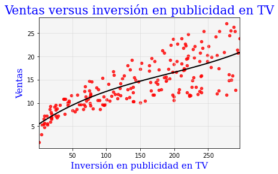

```python
fig = sns.regplot(x="TV",y="sales",data=Advertising,order=3,marker="o",
                  scatter_kws={"s":20,"color":"red"},line_kws={"ls":"solid","lw":2,"color":"black"},ci=None)
plt.xlabel("Inversión en publicidad en TV",fontdict={"family":"serif","color":"blue","size":15})
plt.ylabel("Ventas",fontdict={"family":"serif","color":"blue","size":15})
plt.title("Ventas versus inversión en publicidad en TV",
          fontdict={"family":"serif","color":"blue","size":20},loc="center")
plt.grid(axis="both",color="lightgray",ls="solid",lw=0.5)
fig.patch.set_facecolor("whitesmoke")
plt.show(fig)
```

```python
cats = 3
bins = Advertising["radio"].quantile(np.arange(0,cats+1)/cats)
Advertising["radioC"] = pd.cut(Advertising["radio"],bins,labels=["Baja","Media","Alta"])
```

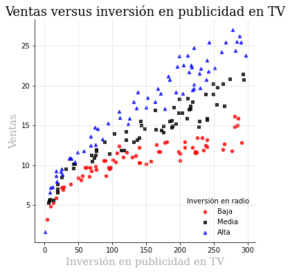

```python
fig = sns.lmplot(x="TV",y="sales",data=Advertising,order=3,hue="radioC",markers=["o","s","^"],
                 palette=dict(Baja="red",Media="black",Alta="blue"),
                 scatter_kws={"s":20},ci=None,legend=False,fit_reg=False,
                 line_kws={"ls":"solid","lw":2})
plt.legend(loc='lower right',title="Inversión en radio",frameon=False,ncol=1)
plt.xlabel("Inversión en publicidad en TV",fontdict={"family":"serif","color":"darkgrey","size":15})
plt.ylabel("Ventas",fontdict={"family":"serif","color":"darkgrey","size":15})
plt.title("Ventas versus inversión en publicidad en TV",
          fontdict={"family":"serif","color":"black","size":18},loc="center")
plt.grid(axis="both",color="lightgray",ls="solid",lw=0.5)
plt.show(fig)
```

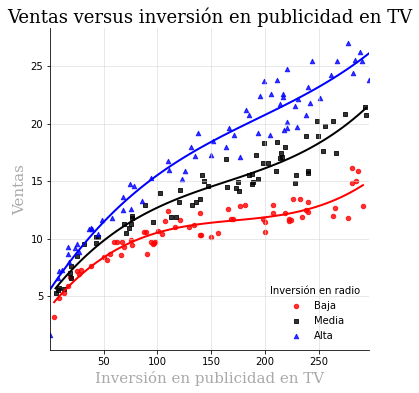

```python
fig = sns.lmplot(x="TV",y="sales",data=Advertising,order=3,hue="radioC",markers=["o","s","^"],
                 palette=dict(Baja="red",Media="black",Alta="blue"),
                 scatter_kws={"s":20},ci=None,legend=False,
                 line_kws={"ls":"solid","lw":2})
plt.legend(loc='lower right',title="Inversión en radio",frameon=False,ncol=1)
plt.xlabel("Inversión en publicidad en TV",fontdict={"family":"serif","color":"darkgrey","size":15})
plt.ylabel("Ventas",fontdict={"family":"serif","color":"darkgrey","size":15})
plt.title("Ventas versus inversión en publicidad en TV",
          fontdict={"family":"serif","color":"black","size":18},loc="center")
plt.grid(axis="both",color="lightgray",ls="solid",lw=0.5)
plt.show(fig)
```

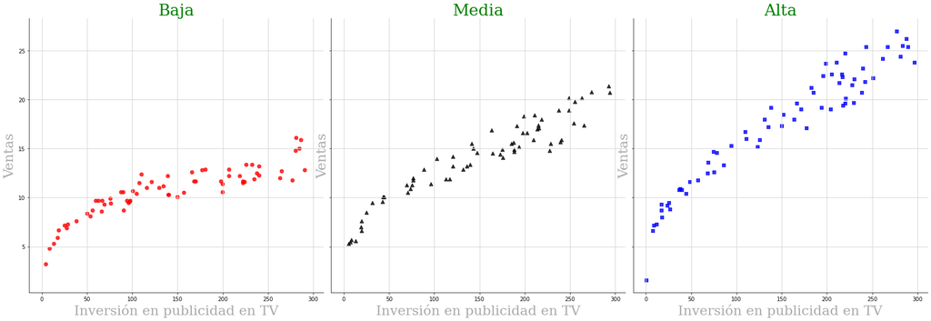

```python
g = sns.FacetGrid(data=Advertising,col="radioC",hue="radioC",sharey=True,height=8,
                  hue_kws=dict(marker=["o","^","s"],color=["red","black","blue"]))
g.map(sns.regplot,"TV","sales",order=3,scatter_kws={"s":45},line_kws={"ls":"solid","lw":1},ci=None,fit_reg=False)
axes = g.axes.flatten()
titulos = ["Baja","Media","Alta"]
for ax in np.arange(0,len(titulos)):
    axes[ax].set_xlabel("Inversión en publicidad en TV",fontdict={"family":"serif","color":"darkgrey","size":25})
    axes[ax].set_ylabel("Ventas",fontdict={"family":"serif","color":"darkgrey","size":25})
    axes[ax].set_title(titulos[ax],fontdict={"family":"serif","color":"green","size":30},loc="center")
    axes[ax].grid(axis="both",color="lightgray",ls="solid",lw=1)
```

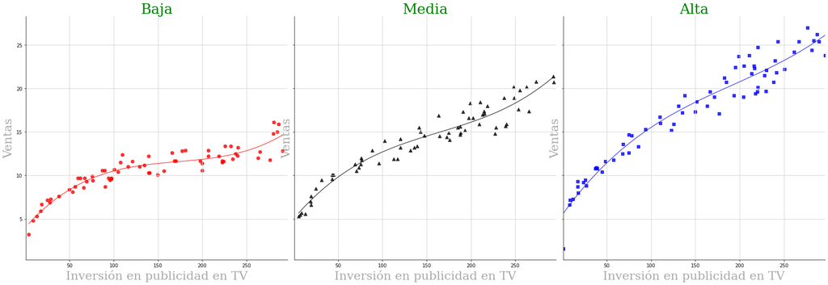

```python
g = sns.FacetGrid(data=Advertising,col="radioC",hue="radioC",sharey=True,height=8,
                  hue_kws=dict(marker=["o","^","s"],color=["red","black","blue"]))
g.map(sns.regplot,"TV","sales",order=3,scatter_kws={"s":45},line_kws={"ls":"solid","lw":1},ci=None)
axes = g.axes.flatten()
titulos = ["Baja","Media","Alta"]
for ax in np.arange(0,len(titulos)):
    axes[ax].set_xlabel("Inversión en publicidad en TV",fontdict={"family":"serif","color":"darkgrey","size":25})
    axes[ax].set_ylabel("Ventas",fontdict={"family":"serif","color":"darkgrey","size":25})
    axes[ax].set_title(titulos[ax],fontdict={"family":"serif","color":"green","size":30},loc="center")
    axes[ax].grid(axis="both",color="lightgray",ls="solid",lw=1)
```

```python
cats = 3
bins = Advertising["TV"].quantile(np.arange(0,cats+1)/cats)
Advertising["TVC"] = pd.cut(Advertising["TV"],bins,labels=["Baja","Media","Alta"])
```

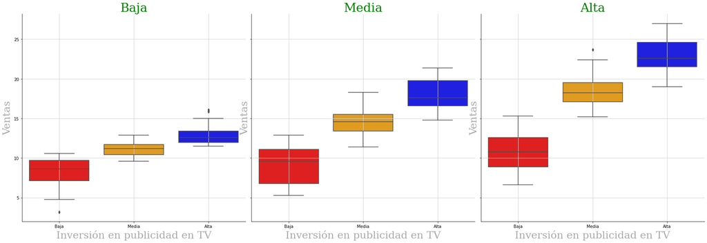

```python
g = sns.FacetGrid(data=Advertising,col="radioC",sharey=True,height=8)
g.map(sns.boxplot,"TVC","sales",order=titulos,palette=dict(Baja="red",Media="orange",Alta="blue"),linewidth=1.5)
axes = g.axes.flatten()
for ax in np.arange(0,len(titulos)):
    axes[ax].set_xlabel("Inversión en publicidad en TV",fontdict={"family":"serif","color":"darkgrey","size":25})
    axes[ax].set_ylabel("Ventas",fontdict={"family":"serif","color":"darkgrey","size":25})
    axes[ax].set_title(titulos[ax],fontdict={"family":"serif","color":"green","size":30},loc="center")
    axes[ax].grid(axis="both",color="lightgray",ls="solid",lw=1)
```

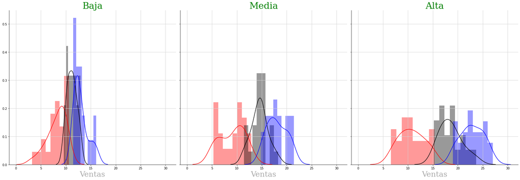

```python
g = sns.FacetGrid(data=Advertising,col="radioC",hue="TVC",sharey=True,height=8,
                 hue_kws=dict(color=["red","black","blue"]))
g.map(sns.distplot,"sales",norm_hist=True,kde=True,bins=8)
axes = g.axes.flatten()
for ax in np.arange(0,len(titulos)):
    axes[ax].set_xlabel("Ventas",fontdict={"family":"serif","color":"darkgrey","size":25})
    axes[ax].set_title(titulos[ax],fontdict={"family":"serif","color":"green","size":30},loc="center")
    axes[ax].grid(axis="both",color="lightgray",ls="solid",lw=1)
```

```python
#sns.get_dataset_names()
cars = sns.load_dataset("mpg")
cars.loc[cars["origin"]=="usa","Origen"] = "Estados Unidos"
cars.loc[cars["origin"]!="usa","Origen"] = "Japón y Europa"
```

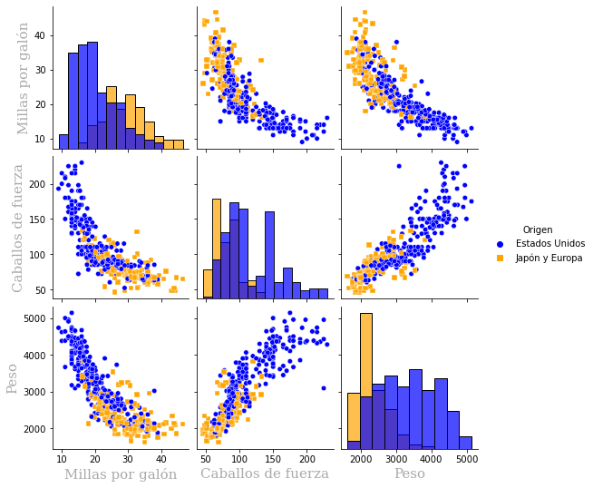

```python
fig = sns.pairplot(cars, vars=["mpg","horsepower","weight"],hue="Origen",kind="scatter",
                   diag_kind="hist",palette=["blue","orange"],
                   markers=["o", "s"],plot_kws={"s":30},diag_kws={"alpha":0.7})
axes = fig.axes.flatten()
titulos = ["Millas por galón","Caballos de fuerza","Peso"]
c = np.sqrt(len(axes))
for ax1 in np.arange(0,c):
    for ax2 in np.arange(0,c):
        ax = int(ax1*c + ax2)
        if ax2 == 0: axes[ax].set_ylabel(titulos[int(ax1)],fontdict={"family":"serif","color":"darkgrey","size":15})
        if ax1 == c-1: axes[ax].set_xlabel(titulos[int(ax2)],fontdict={"family":"serif","color":"darkgrey","size":15})
plt.show(fig)
```

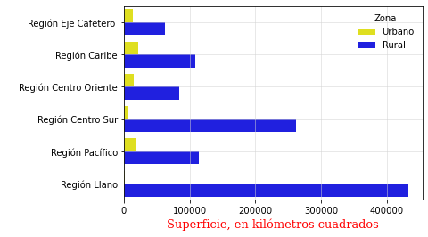

```python
fig=sns.barplot(y="Region",x="Superficie",hue="Zona",data=Municipios,estimator=sum,ci=None,
                palette=dict(Rural="blue",Urbano="yellow"))
plt.xlabel("Superficie, en kilómetros cuadrados",fontdict={"family":"serif","color":"red","size":13})
plt.ylabel(" ")
plt.legend(loc='upper right',title="Zona",frameon=False,ncol=1)
plt.grid(axis="both",color="lightgray",ls="solid",lw=0.5)
plt.show(fig)
```

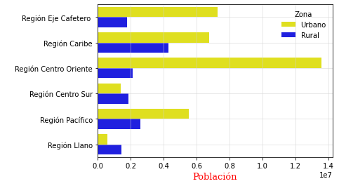

```python
fig=sns.barplot(y="Region",x="Poblacion",hue="Zona",data=Municipios,estimator=sum,ci=None,
                palette=dict(Rural="blue",Urbano="yellow"))
plt.xlabel("Población",fontdict={"family":"serif","color":"red","size":13})
plt.ylabel(" ")
plt.legend(loc='upper right',title="Zona",frameon=False,ncol=1)
plt.grid(axis="both",color="lightgray",ls="solid",lw=0.5)
plt.show(fig)
```